# 20200828_Pathak_Vinayak_HW1

Vinayak Pathak

8/28/2020

# Section A

1. Read in the data file titled *Chr20ex.csv*.

```r
df <- read.table(file = "Chr20ex.csv", header = FALSE)
head(df)
```

```
##   V1       V2          V3  V4 V5  V6   V7
## 1 20 62940524 rs562989767   C  T 100 PASS
## 2 20 62940562 rs202197845 CCT  C 100 PASS
## 3 20 62940717 rs531662157   C  T 100 PASS
## 4 20 62940801 rs551961101   T  C 100 PASS
## 5 20 62940873 rs571836817   G  A 100 PASS
## 6 20 62940984 rs528014419   C  T 100 PASS
```

2. Use summary to show the summary statistics for the Chromosome 20 dataframe. Print the summary.

```r
summary(df)
```

```
##        V1           V2                V3                 V4
##  Min.   :20   Min.   :62940524   Length:500         Length:500
##  1st Qu.:20   1st Qu.:62948730   Class :character   Class :character
##  Median :20   Median :62954221   Mode  :character   Mode  :character
##  Mean   :20   Mean   :62953882
##  3rd Qu.:20   3rd Qu.:62958690
##  Max.   :20   Max.   :62965354
##       V5                  V6           V7
##  Length:500         Min.   :100   Length:500
##  Class :character   1st Qu.:100   Class :character
##  Mode  :character   Median :100   Mode  :character
##                     Mean   :100
##                     3rd Qu.:100
##                     Max.   :100
```

How many rows are there in this dataframe? Ans: There are 500 rows and hence 500 records in the database

```r
dim(df)[1]
```

```
## [1] 500
```

3. How many of the data points “PASS” the quality test?

```r
df_pass <- df %>%
  filter(V7 == "PASS")
c<-count(df_pass)
cat("The number of data points that pass the quality tests are",c[[1]])
```

```
## The number of data points that pass the quality tests are 500
```

Therefore total 500 records within the PASS Variable

4. How many C->T SNPs exist in the data? (Hint- This is where the REF is a C and the ALT is a T)

```r
df_c_t <- df %>%
  filter(V4 == "C", V5 =='T')
cat("The number of C -> T SNPs in the dataset are",count(df_c_t)[1, ])
```

```
## The number of C -> T SNPs in the dataset are 116
```

There for total 116 records with C->T SNPs in the Data

5. Plot a histogram of A,C,T,G in Chromosome 20 dataframe using [ggplot2](https://tutorials.iq.harvard.edu/R/Rgraphics/Rgraphics.html). You may have to install.packages(“ggplot2”) and read through the ggplot tutorial.

```r
head(df_c_t)
```

```
##   V1       V2          V3 V4 V5  V6   V7
## 1 20 62940524 rs562989767  C  T 100 PASS
## 2 20 62940717 rs531662157  C  T 100 PASS
## 3 20 62940984 rs528014419  C  T 100 PASS
## 4 20 62941101 rs548089068  C  T 100 PASS
## 5 20 62942259 rs543011885  C  T 100 PASS
## 6 20 62942770 rs545492729  C  T 100 PASS
```

```r
count(df_c_t)
```

```
##     n
## 1 116
```

Extracting the correct rows as tibble and then plotting the graph Renaming the columns

Plotting the chromosome histogram...

```r
count_bp = 0;
counter = 1
list_bases <-c("A", "T", "G","C")
for (i in list_bases)
{count_bp[counter]<- sum(as.numeric(as.logical(df$V5==i)));
counter=counter+1
}
```

```r
df_final <-as.data.frame(list_bases)
df_final <-cbind(df_final, count_bp)
```

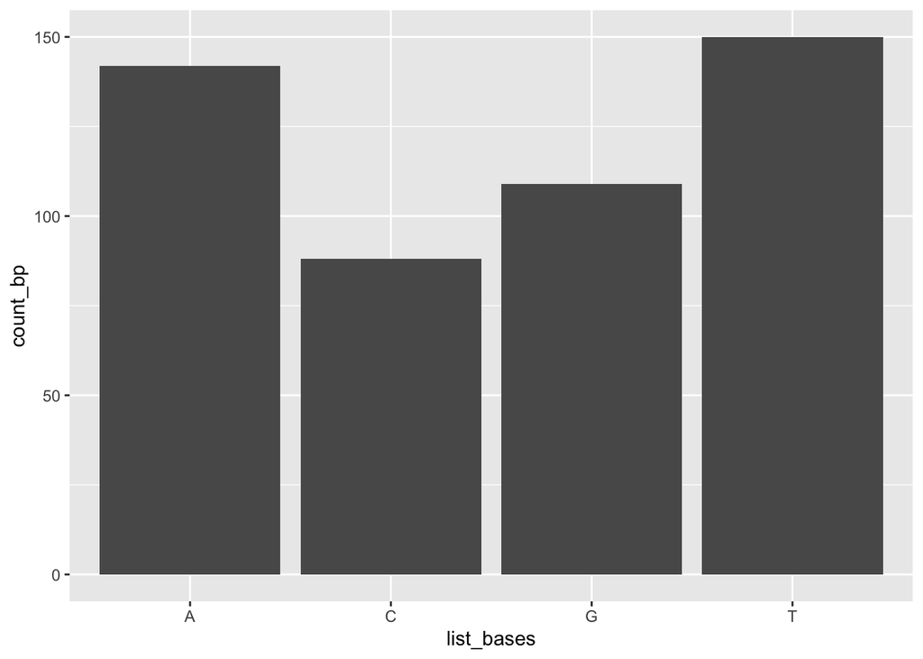

```r
g <- ggplot(df_final, aes(x=list_bases, y=count_bp))+geom_histogram(stat = "Identity")
plot(g)
```

```r
#g <- ggplot(df_pass, aes(x = V5, y=as.numeric(as.logical(count_bp))))
#g <- ggplot(df_pass, aes(y=as.numeric(as.logical(count_bp))))
```

# Section B

1. Download Heart Disease data set from UCI Machine Learning Repository using the following bash command. Bash chunk can be inserted by clicking on the drop-down menu beside the **Insert** at the top-left of the editor. **wget** is a bash tool that can be easily downloaded and installed on your computer. Depending on your operating system and package management preferences, you will have to install wget through different methods. Please search on Google on how to install wget.

```bash
wget https://archive.ics.uci.edu/ml/machine-learning-databases/heart-disease/processed.cleveland.data
```

```r
df_hd <-read.table(file = "processed.cleveland.data", header =TRUE, sep =",")
```

2. Import the file into R and label the column names properly. Note you can get some necessary information from the [archive](https://archive.ics.uci.edu/ml/datasets/Heart+Disease). Print the first few lines of the dataframe including your header row. How many rows and columns are there in this dataset?

```r
list_attrib <- c("age", "sex", "cp", "trestbps", "chol", "fbs", "restecg", "thalach", "exang", "oldpeak", "slope", "ca", "thal", "num")
```

```r
col_df = colnames(df_hd)
```

Renaming the columns of the dataframe

```r
#for(i in 2:length(col_df))

names(df_hd) <- list_attrib
```

```r
col_df_mod <-colnames(df_hd)
col_df_mod
```

```
##  [1] "age"      "sex"      "cp"       "trestbps" "chol"     "fbs"
##  [7] "restecg"  "thalach"  "exang"    "oldpeak"  "slope"    "ca"
## [13] "thal"     "num"
```

```r
head(df_hd)
```

```
##   age sex cp trestbps chol fbs restecg thalach exang oldpeak slope  ca thal num
## 1  67   1  4      160  286   0       2     108     1     1.5     2 3.0  3.0   2
## 2  67   1  4      120  229   0       2     129     1     2.6     2 2.0  7.0   1
## 3  37   1  3      130  250   0       0     187     0     3.5     3 0.0  3.0   0
## 4  41   0  2      130  204   0       2     172     0     1.4     1 0.0  3.0   0
## 5  56   1  2      120  236   0       0     178     0     0.8     1 0.0  3.0   0
## 6  62   0  4      140  268   0       2     160     0     3.6     3 2.0  3.0   3
```

```r
dim(df_hd)
```

```
## [1] 302  14
```

Total number of rows and columns in the the data frame are 302 and 14; therefore there are total 302 records and 14 attributes for each of the record.

3. The last column of the data contains diagnosis information ranging from 0 to 4. The “0” label indicates that the subject is healthy, whereas the subjects with non-zero value in this field are positively diagnosed with heart disease. Using dplyr, add a new column named “diagnosed” that contains binary information about whether the subject has heart disease or not (e.g. true/false, 0/1, etc). Print the first few rows of your dataframe to confirm you have successfully created the new column.

```r
df_hd <- mutate(df_hd, diagnosed = (num>0))
```

An example of the display...

```r
head(df_hd) %>%
  select(age, sex, num, diagnosed)
```

```
##   age sex num diagnosed
## 1  67   1   2      TRUE
## 2  67   1   1      TRUE
## 3  37   1   0     FALSE
## 4  41   0   0     FALSE
## 5  56   1   0     FALSE
## 6  62   0   3      TRUE
```

4. Write a function that takes in a dataframe and a column name of the dataframe and prints the summary statistics of values in that dataframe. You should follow this logic with potential improvements:
- If the values are numeric, print that the values are numeric and then print the maximum value, minimum value, mean and median.
- If the values are characters, categorical or logical, print the data type and then print the counts of each existing values.
- You should also check that the column name provided by the user of this function is indeed a column of the dataframe provided by the user as well. Check this and output appropriate error message.

Following is the function to be defined...

```r
summarize_column <- function(dfn, column_name) {
  if (!column_name %in% names(dfn)) {
    stop(cat("The queried column name", column_name, "is not a valid dataframe attribute please enter the correct column name"))
  }
temp <- summary(dfn
        %>%select(column_name))

print(temp)
vectemp <- cat("The class of asked variable", column_name, "is", class(dfn[[column_name]]), "\n")
}
```

```r
summarize_column(df_hd, "age")
```

```
## Note: Using an external vector in selections is ambiguous.
## ℹ Use `all_of(column_name)` instead of `column_name` to silence this message.
## ℹ See <https://tidyselect.r-lib.org/reference/faq-external-vector.html>.
```

```
##       age
##  Min.   :29.00
##  1st Qu.:48.00
##  Median :55.50
##  Mean   :54.41
##  3rd Qu.:61.00
##  Max.   :77.00
## The class of asked variable age is numeric
```

```r
summarize_column(df_hd, "diagnosed")
```

```
##  diagnosed
##  Mode :logical
##  FALSE:163
##  TRUE :139
## The class of asked variable diagnosed is logical
```

```r
summarize_column(df_hd, "random")
```

```
## The queried column name random is not a valid dataframe attribute please enter the correct column name
```

```
## Error in summarize_column(df_hd, "random"):
```

Test for the chr_20 database

```r
summarize_column(df, "V5")
```

```
##       V5
##  Length:500
##  Class :character
##  Mode  :character
## The class of asked variable V5 is character
```

```r
summarize_column(df, "V1")
```

```
##        V1
##  Min.   :20
##  1st Qu.:20
##  Median :20
##  Mean   :20
##  3rd Qu.:20
##  Max.   :20
## The class of asked variable V1 is integer
```

```r
summarize_column(df, "random")
```

```
## The queried column name random is not a valid dataframe attribute please enter the correct column name
```

```
## Error in summarize_column(df, "random"):
```

# Section C

1. Look at the first 5 lines and last 5 lines of the data file owid-covid-data.csv.gz without unzipping it (This is not a very large dataset per se, but is used to simulate a working with a large dataset). Find out what "gzcat" does by running "man gzcat" and use "gzcat" to complete this task.

Printing thhe first 5 lines without unzipping

```bash
gzcat owid-covid-data.csv.gz| head -n 5
```

```
## iso_code,continent,location,date,total_cases,new_cases,new_cases_smoothed,total_deaths,new_deaths,new_deaths_smoothed,total_cases_per_million,new_cases_per_million,new_cases_smoothed_per_million,total_deaths_per_million,new_deaths_per_million,new_deaths_smoothed_per_million,new_tests,total_tests,…
## ABW,North America,Aruba,2020-03-13,2.0,2.0,,0.0,0.0,,18.733,18.733,,0.0,0.0,,,,,,,,,,,0.0,106766.0,584.8,41.2,13.085,7.452,35973.781,,,11.62,,,,,76.29
## ABW,North America,Aruba,2020-03-19,,,0.286,,,0.0,,,2.676,,,0.0,,,,,,,,,,33.33,106766.0,584.8,41.2,13.085,7.452,35973.781,,,11.62,,,,,76.29
## ABW,North America,Aruba,2020-03-20,4.0,2.0,0.286,0.0,0.0,0.0,37.465,18.733,2.676,0.0,0.0,0.0,,,,,,,,,,33.33,106766.0,584.8,41.2,13.085,7.452,35973.781,,,11.62,,,,,76.29
## ABW,North America,Aruba,2020-03-21,,,0.286,,,0.0,,,2.676,,,0.0,,,,,,,,,,44.44,106766.0,584.8,41.2,13.085,7.452,35973.781,,,11.62,,,,,76.29
```

Printing the last 5 lines of the files without unzipping

```bash
gzcat owid-covid-data.csv.gz| tail -n 5
```

```
## ,,International,2020-08-20,696.0,,,7.0,,,,,,,,,,,,,,,,,,,,,,,,,,,,,,,,
## ,,International,2020-08-21,696.0,,,7.0,,,,,,,,,,,,,,,,,,,,,,,,,,,,,,,,
## ,,International,2020-08-22,696.0,,,7.0,,,,,,,,,,,,,,,,,,,,,,,,,,,,,,,,
## ,,International,2020-08-23,696.0,,,7.0,,,,,,,,,,,,,,,,,,,,,,,,,,,,,,,,
## ,,International,2020-08-24,696.0,,,7.0,,,,,,,,,,,,,,,,,,,,,,,,,,,,,,,,
```

2. How many lines are there in this file? Find out without unzipping the file.

Printing the number of lines in the file:(Includes, the heading)

```bash
gzcat owid-covid-data.csv.gz| wc -l
```

```
##    39272
```

3. Unzip owid-covid-data.csv.gz without deleting the original zipped file. Use "man gunzip" to find out how to do that.

Unzipping the file owid-covid-data.csv.gz

```bash
gunzip owid-covid-data.csv.gz
```

```
## gunzip: owid-covid-data.csv already exists -- skipping
```

4. Find out how many days of COVID-19 data *Italy* has in this dataset. Use "grep" to find the lines that contain the work "Italy" and count the lines.

using grep to find the numbaer of occurences of the word *Italy and count those lines

```bash
grep Italy owid-covid-data.csv|wc -l
```

```
##      238
```

So there are 238 lines with occurrences of Italy

5. Look at "owid_covid_codebook.csv", which is a data dictionary for "owid_covid_data.csv". Each row is a COVID-19 case count entry. How many columns and how many rows are there in this dataset? Find out which column indicates the country from the codebook. Use bash command to determine how many unique countries have data in this file. I recommend using "awk" to parse the file.

Find out how many rows and columns in this file using awk

```bash
awk -F"," '{print NF}' owid-covid-data.csv | sort | uniq -c
```

```
## 39272 40
```

There are 39272 rows(including heading) and 40 columns/attributes in the file.

location i.e. column 3 or $3 indicates the country from the code book Reading into a data base to verify id the findings are correct

```r
#df_covid <- read.csv2(file = "owid-covid-data.csv", sep = ",")
```

Finding the number of unique countries that have their data in this data base

```bash
awk -F "," '$3!="location" {print $3}' owid-covid-data.csv|uniq|wc -l
```

```
##      212
```

Therefore there are 212 unique countries that have their data in this file.

Finding out which column gives the output as total cases

```bash
awk 'BEGIN {FS = ",";counter = 1}; $1=="iso_code" {while($counter!="total_cases"){counter+=1}};END{ print counter}' owid-covid-data.csv|head -1
```

```
## 5
```

Fifth column is the column with total cases

Finding out which column gives the output as single daily new_cases

```bash
awk 'BEGIN {FS = ",";counter = 1}; $1=="iso_code" {while($counter!="new_cases"){counter+=1}};END{ print counter}' owid-covid-data.csv|head -1
```

```
## 6
```

Therefore sixth column gives the single daily 'new_cases' 6. Use "awk" to filter by country "iso_code" so that we are only looking at COVID data from the USA. Find out the date that has the largest number of single day new cases in the USA using "sort".

```bash
awk -F "," '$1=="USA" {print $5, $4}' owid-covid-data.csv|sort -n|tail -1
```

```
## 5702611.0 2020-08-24
```

Therefore the date is 2020-08-24 when the total number of cases are maximum

```bash
awk -F "," '$1=="USA" {print $6, $4}' owid-covid-data.csv|sort -n|tail -1
```

```
## 78427.0 2020-07-25
```